# Titanic Project

In this progect we analize titanic data to found the factors that affect passenger surviveling. We will focus on passenger class that we get it from ticket class. We expect that passengers with high class will have better chance to survived.

## About Titanic

RMS Titanic is infamous ship sank in the North Atlantic Ocean in the 15th of April ,1912 after colliding with an iceberg. This disaster killing 1502 out of 2224 passengers and crew. One of the main reasons of large death is the less of lifboots on the ship.

```python
#Load Titanic Data from CSVs
import numpy as np
import pandas as pd
import matplotlib.pyplot as plt
import seaborn as sns

Passengers = pd.read_csv('titanic-data.csv')
```

```python
#take a look on the data
Passengers.head()
```

|  | PassengerId | Survived | Pclass | Name | Sex | Age | SibSp | Parch | Ticket | Fare | Cabin | Embarked |
| --- | --- | --- | --- | --- | --- | --- | --- | --- | --- | --- | --- | --- |
| 0 | 1 | 0 | 3 | Braund, Mr. Owen Harris | male | 22.0 | 1 | 0 | A/5 21171 | 7.2500 | NaN | S |
| 1 | 2 | 1 | 1 | Cumings, Mrs. John Bradley (Florence Briggs Th... | female | 38.0 | 1 | 0 | PC 17599 | 71.2833 | C85 | C |
| 2 | 3 | 1 | 3 | Heikkinen, Miss. Laina | female | 26.0 | 0 | 0 | STON/O2. 3101282 | 7.9250 | NaN | S |
| 3 | 4 | 1 | 1 | Futrelle, Mrs. Jacques Heath (Lily May Peel) | female | 35.0 | 1 | 0 | 113803 | 53.1000 | C123 | S |
| 4 | 5 | 0 | 3 | Allen, Mr. William Henry | male | 35.0 | 0 | 0 | 373450 | 8.0500 | NaN | S |

```python
#describe data using staitic measures
Passengers.describe()
```

|  | PassengerId | Survived | Pclass | Age | SibSp | Parch | Fare |
| --- | --- | --- | --- | --- | --- | --- | --- |
| count | 891.000000 | 891.000000 | 891.000000 | 714.000000 | 891.000000 | 891.000000 | 891.000000 |
| mean | 446.000000 | 0.383838 | 2.308642 | 29.699118 | 0.523008 | 0.381594 | 32.204208 |
| std | 257.353842 | 0.486592 | 0.836071 | 14.526497 | 1.102743 | 0.806057 | 49.693429 |
| min | 1.000000 | 0.000000 | 1.000000 | 0.420000 | 0.000000 | 0.000000 | 0.000000 |
| 25% | 223.500000 | 0.000000 | 2.000000 | 20.125000 | 0.000000 | 0.000000 | 7.910400 |
| 50% | 446.000000 | 0.000000 | 3.000000 | 28.000000 | 0.000000 | 0.000000 | 14.454200 |
| 75% | 668.500000 | 1.000000 | 3.000000 | 38.000000 | 1.000000 | 0.000000 | 31.000000 |
| max | 891.000000 | 1.000000 | 3.000000 | 80.000000 | 8.000000 | 6.000000 | 512.329200 |

```python
#group survived passengers and non survived ones.
Survive_Passengers = Passengers.groupby('Survived', as_index=False)
Survive_Passengers.describe()
```

|  |  | PassengerId | Survived | Pclass | Age | SibSp | Parch | Fare |
| --- | --- | --- | --- | --- | --- | --- | --- | --- |
| 0 | count | 549.000000 | 549.0 | 549.000000 | 424.000000 | 549.000000 | 549.000000 | 549.000000 |
|  | mean | 447.016393 | 0.0 | 2.531876 | 30.626179 | 0.553734 | 0.329690 | 22.117887 |
|  | std | 260.640469 | 0.0 | 0.735805 | 14.172110 | 1.288399 | 0.823166 | 31.388207 |
|  | min | 1.000000 | 0.0 | 1.000000 | 1.000000 | 0.000000 | 0.000000 | 0.000000 |
|  | 25% | 211.000000 | 0.0 | 2.000000 | 21.000000 | 0.000000 | 0.000000 | 7.854200 |
|  | 50% | 455.000000 | 0.0 | 3.000000 | 28.000000 | 0.000000 | 0.000000 | 10.500000 |
|  | 75% | 675.000000 | 0.0 | 3.000000 | 39.000000 | 1.000000 | 0.000000 | 26.000000 |
|  | max | 891.000000 | 0.0 | 3.000000 | 74.000000 | 8.000000 | 6.000000 | 263.000000 |
| 1 | count | 342.000000 | 342.0 | 342.000000 | 290.000000 | 342.000000 | 342.000000 | 342.000000 |
|  | mean | 444.368421 | 1.0 | 1.950292 | 28.343690 | 0.473684 | 0.464912 | 48.395408 |
|  | std | 252.358840 | 0.0 | 0.863321 | 14.950952 | 0.708688 | 0.771712 | 66.596998 |
|  | min | 2.000000 | 1.0 | 1.000000 | 0.420000 | 0.000000 | 0.000000 | 0.000000 |
|  | 25% | 250.750000 | 1.0 | 1.000000 | 19.000000 | 0.000000 | 0.000000 | 12.475000 |
|  | 50% | 439.500000 | 1.0 | 2.000000 | 28.000000 | 0.000000 | 0.000000 | 26.000000 |
|  | 75% | 651.500000 | 1.0 | 3.000000 | 36.000000 | 1.000000 | 1.000000 | 57.000000 |
|  | max | 890.000000 | 1.0 | 3.000000 | 80.000000 | 4.000000 | 5.000000 | 512.329200 |

## Data overview

titanic dataset contains data of 891 passengers and just 38.38% of them are survived. The average of passenger age is 29.7 years. survivling is the dependent variable and other varibals like age, gender, and class will be the independent variables. We can see some groups of people are more likely to survive than others. The upper class have large persentage to survive than lower class. The mean of survived ages is lower than unsurvived ones.

## Project Questions

1- What factors made people more likely to survive?

```
a. Is the class of passenger made people more likely to survive?
b. Is famliy relations made people more likely to survive?
c. Is the class of passenger made people more likely to survive?
d. Is having family person on the ship made people more likely to survive?
```

2- Is sex has diffrent effect on surviveing rate for various classes ?

3- Is age has diffrent effect on surviveing rate for various classes ?

4- Are age and sex have diffrent effect on surviveing rate for various classes ?

## Data wrangling

titanic dataset is incompleat dataset because it contain data of 891 from 2224 passengers. titanic datasethave some missdata. the age of 177 Passengers is missing. We will drop the passenger records that have missing ages to obtain more accurate results. The updated dataset will used when we anlayse based on ages. there are some changes after removing passenngers with missing ages. For example,the surviving rate incresesd by 2.23%. This means that most of missing ages for unsurvived passengers it maybe because we can gather data from survived passenger.

```python
#Updated_Passengers = Passengers['Age'].fillna(29.7)
print ('Before' , len(Passengers))
Updated_Passengers = Passengers.dropna(subset = ['Age'])
print ('After' , len(Updated_Passengers))
```

```
('Before', 891)
('After', 714)
```

```python
#After removing missing ages
Updated_Passengers.describe()
```

|  | PassengerId | Survived | Pclass | Age | SibSp | Parch | Fare |
| --- | --- | --- | --- | --- | --- | --- | --- |
| count | 714.000000 | 714.000000 | 714.000000 | 714.000000 | 714.000000 | 714.000000 | 714.000000 |
| mean | 448.582633 | 0.406162 | 2.236695 | 29.699118 | 0.512605 | 0.431373 | 34.694514 |
| std | 259.119524 | 0.491460 | 0.838250 | 14.526497 | 0.929783 | 0.853289 | 52.918930 |
| min | 1.000000 | 0.000000 | 1.000000 | 0.420000 | 0.000000 | 0.000000 | 0.000000 |
| 25% | 222.250000 | 0.000000 | 1.000000 | 20.125000 | 0.000000 | 0.000000 | 8.050000 |
| 50% | 445.000000 | 0.000000 | 2.000000 | 28.000000 | 0.000000 | 0.000000 | 15.741700 |
| 75% | 677.750000 | 1.000000 | 3.000000 | 38.000000 | 1.000000 | 1.000000 | 33.375000 |
| max | 891.000000 | 1.000000 | 3.000000 | 80.000000 | 5.000000 | 6.000000 | 512.329200 |

```python
#After removing missing ages
Survive_Passengers = Updated_Passengers.groupby('Survived', as_index=False)
Survive_Passengers.describe()
```

|  |  | PassengerId | Survived | Pclass | Age | SibSp | Parch | Fare |
| --- | --- | --- | --- | --- | --- | --- | --- | --- |
| 0 | count | 424.000000 | 424.0 | 424.000000 | 424.000000 | 424.000000 | 424.000000 | 424.000000 |
|  | mean | 442.299528 | 0.0 | 2.485849 | 30.626179 | 0.525943 | 0.365566 | 22.965456 |
|  | std | 264.739548 | 0.0 | 0.743633 | 14.172110 | 1.044760 | 0.878341 | 31.448825 |
|  | min | 1.000000 | 0.0 | 1.000000 | 1.000000 | 0.000000 | 0.000000 | 0.000000 |
|  | 25% | 200.750000 | 0.0 | 2.000000 | 21.000000 | 0.000000 | 0.000000 | 7.895800 |
|  | 50% | 436.000000 | 0.0 | 3.000000 | 28.000000 | 0.000000 | 0.000000 | 11.887500 |
|  | 75% | 683.250000 | 0.0 | 3.000000 | 39.000000 | 1.000000 | 0.000000 | 26.550000 |
|  | max | 891.000000 | 0.0 | 3.000000 | 74.000000 | 5.000000 | 6.000000 | 263.000000 |
| 1 | count | 290.000000 | 290.0 | 290.000000 | 290.000000 | 290.000000 | 290.000000 | 290.000000 |
|  | mean | 457.768966 | 1.0 | 1.872414 | 28.343690 | 0.493103 | 0.527586 | 51.843205 |
|  | std | 250.845515 | 0.0 | 0.836617 | 14.950952 | 0.731132 | 0.807147 | 70.458776 |
|  | min | 2.000000 | 1.0 | 1.000000 | 0.420000 | 0.000000 | 0.000000 | 0.000000 |
|  | 25% | 260.500000 | 1.0 | 1.000000 | 19.000000 | 0.000000 | 0.000000 | 13.000000 |
|  | 50% | 452.000000 | 1.0 | 2.000000 | 28.000000 | 0.000000 | 0.000000 | 26.250000 |
|  | 75% | 669.500000 | 1.0 | 3.000000 | 36.000000 | 1.000000 | 1.000000 | 66.200000 |
|  | max | 890.000000 | 1.0 | 3.000000 | 80.000000 | 4.000000 | 5.000000 | 512.329200 |

## Investigating the Data

We start investigating titanic data and try to answering the previose questions.

```python
#Age {Child 0-13 Teenager 13-20 Young_Adult20-45 Middle_age45-65 Old_age65-80}
Age_Passengers = Updated_Passengers
Age_Passengers['Age_range'] = pd.cut(Age_Passengers['Age'], bins=[0, 13, 20, 45, 65, 80],
                                     labels='Child Teenager Young_Adult Middle_age Old_age'.split())
labels = np.array('Child Teenager Young_Adult Middle_age Old_age'.split())


Age_Passengers = Age_Passengers.groupby('Age_range', as_index=False)
Age_Passengers['Survived'].describe()
#Age_Passengers = Passengers.groupby('Age', as_index=False)
#Age_Passengers.describe()
```

|  | count | mean | std | min | 25% | 50% | 75% | max |
| --- | --- | --- | --- | --- | --- | --- | --- | --- |
| 0 | 71.0 | 0.591549 | 0.495046 | 0.0 | 0.0 | 1.0 | 1.0 | 1.0 |
| 1 | 108.0 | 0.370370 | 0.485155 | 0.0 | 0.0 | 0.0 | 1.0 | 1.0 |
| 2 | 432.0 | 0.393519 | 0.489097 | 0.0 | 0.0 | 0.0 | 1.0 | 1.0 |
| 3 | 95.0 | 0.389474 | 0.490218 | 0.0 | 0.0 | 0.0 | 1.0 | 1.0 |
| 4 | 8.0 | 0.125000 | 0.353553 | 0.0 | 0.0 | 0.0 | 0.0 | 1.0 |

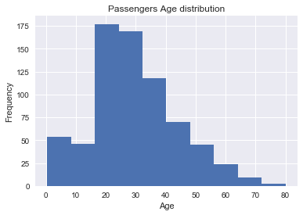

```python
%matplotlib inline
#title="Passengers Age distribution"
pl = Updated_Passengers['Age'].hist()
pl.set_title('Passengers Age distribution')
pl.set_xlabel('Age')
pl.set_ylabel('Frequency')
```

In the above digram we can notic that most of passenger between 20 and 30 years.

```python
Sex_Passengers = Updated_Passengers.groupby('Sex', as_index=False)
Sex_Passengers['Survived'].describe()
```

|  | count | mean | std | min | 25% | 50% | 75% | max |
| --- | --- | --- | --- | --- | --- | --- | --- | --- |
| 0 | 261.0 | 0.754789 | 0.431039 | 0.0 | 1.0 | 1.0 | 1.0 | 1.0 |
| 1 | 453.0 | 0.205298 | 0.404366 | 0.0 | 0.0 | 0.0 | 0.0 | 1.0 |

```python
Class_Passengers = Updated_Passengers.groupby('Pclass', as_index=False)
Class_Passengers['Survived'].describe()
```

|  | count | mean | std | min | 25% | 50% | 75% | max |
| --- | --- | --- | --- | --- | --- | --- | --- | --- |
| 0 | 186.0 | 0.655914 | 0.476352 | 0.0 | 0.0 | 1.0 | 1.0 | 1.0 |
| 1 | 173.0 | 0.479769 | 0.501041 | 0.0 | 0.0 | 0.0 | 1.0 | 1.0 |
| 2 | 355.0 | 0.239437 | 0.427342 | 0.0 | 0.0 | 0.0 | 0.0 | 1.0 |

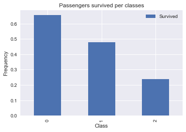

```python
pl = Class_Passengers.Survived.mean().drop('Pclass', axis=1).plot(kind = 'bar',title="Passengers survived per classes")
pl.set_xlabel('Class')
pl.set_ylabel('Frequency')
```

```python
#group the passenger with one or more family person
print "Have family"
have_family = (Updated_Passengers['SibSp'] > 0 )|(Updated_Passengers['Parch'] > 0)
family_passenger = Updated_Passengers[have_family]
print family_passenger['Survived'].describe()

print"\nHave no family"
no_family_passenger = Updated_Passengers[~have_family]
print no_family_passenger['Survived'].describe()

#SibSp_Passengers = Passengers.groupby(['SibSp'], as_index=False)
#SibSp_Passengers['Survived'].describe()
```

```
Have family
count    310.000000
mean       0.516129
std        0.500548
min        0.000000
25%        0.000000
50%        1.000000
75%        1.000000
max        1.000000
Name: Survived, dtype: float64

Have no family
count    404.000000
mean       0.321782
std        0.467739
min        0.000000
25%        0.000000
50%        0.000000
75%        1.000000
max        1.000000
Name: Survived, dtype: float64
```

## 1- What factors made people more likely to survive?

Childern are more likly to survive than other ages.they have 59.15% to survive which corresponds with giving proiraty salvage for women and children.

Females are more likly to survive than males with 54.95% which corresponds with giving proiraty salvage for women and children.

#### c. Is the class of passenger made people more likely to survive?

Upper class passenger are more likly to survive. This maybe that lower class passengers cabins are in bottom of the ship then they take time to reach rescue boats or don't found empty rescue boats.

```python
SC_Passengers = Passengers.groupby(['Pclass','Sex'], as_index=False)
#SC_Passengers.Survived.describe()
SC_Passengers.Survived.agg(['count','mean'])
```

| Pclass | Sex | count | mean |
| --- | --- | --- | --- |
| 1 | female | 94 | 0.968085 |
|  | male | 122 | 0.368852 |
| 2 | female | 76 | 0.921053 |
|  | male | 108 | 0.157407 |
| 3 | female | 144 | 0.500000 |
|  | male | 347 | 0.135447 |

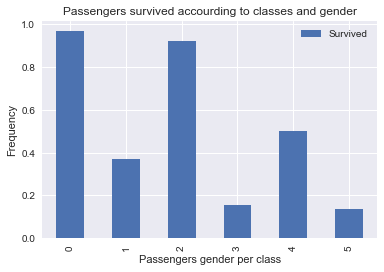

```python
pl = SC_Passengers.Survived.mean().drop('Pclass', axis=1).plot(kind='bar',
                                        title="Passengers survived accourding to classes and gender")

pl.set_xlabel('Passengers gender per class')
pl.set_ylabel('Frequency')
```

```
[0.968085, 0.368852, 0.921053, 0.157407, 0.5, 0.135447]
```

```
(-1.2009707079027925,
 1.1584618584433048,
 -1.2021072296146831,
 1.161740018889825)
```

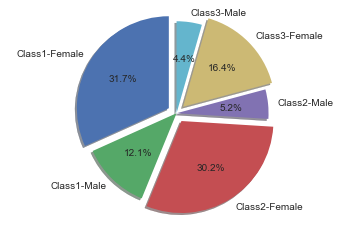

```python
# Pie chart, where the slices will be ordered and plotted counter-clockwise:
labels = 'Class1-Female', 'Class1-Male', 'Class2-Female', 'Class2-Male','Class3-Female', 'Class3-Male'
sizes =  [0.968085, 0.368852, 0.921053, 0.157407, 0.5, 0.135447]
print sizes
explode = (0.1, 0, 0.1, 0, 0.1, 0)  # only "explode" the 2nd slice (i.e. 'Hogs')

fig1, ax1 = plt.subplots()

ax1.pie(sizes, explode=explode, labels=labels, autopct='%1.1f%%',
        shadow=True, startangle=90)
#why set_title didn't work ??
ax1.set_title ='Passengers survived accourding to classes and gender'
ax1.axis('equal')  # Equal aspect ratio ensures that pie is drawn as a circle.
```

## 2- Is sex has diffrent effect on surviveing rate for various classes ?

```python
AC_Passengers = Updated_Passengers.groupby(['Pclass','Age_range'], as_index=False)
AC_Passengers.Survived.agg(['count','mean'])
```

| Pclass | Age_range | count | mean |
| --- | --- | --- | --- |
| 1 | Child | 4 | 0.750000 |
|  | Teenager | 17 | 0.823529 |
|  | Young_Adult | 103 | 0.728155 |
|  | Middle_age | 58 | 0.500000 |
|  | Old_age | 4 | 0.250000 |
| 2 | Child | 18 | 1.000000 |
|  | Teenager | 17 | 0.470588 |
|  | Young_Adult | 115 | 0.434783 |
|  | Middle_age | 21 | 0.333333 |
|  | Old_age | 2 | 0.000000 |
| 3 | Child | 49 | 0.428571 |
|  | Teenager | 74 | 0.243243 |
|  | Young_Adult | 214 | 0.210280 |
|  | Middle_age | 16 | 0.062500 |
|  | Old_age | 2 | 0.000000 |

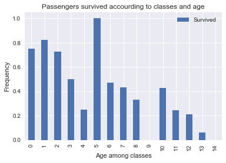

```python
pl = AC_Passengers.Survived.mean().drop('Pclass', axis=1).plot(kind='bar',
                                            title="Passengers survived accourding to classes and age")
pl.set_xlabel('Age among classes')
pl.set_ylabel('Frequency')
```

## 3- Is age has diffrent effect on surviveing rate for various classes ?

We can see that lower ages are more likely to survived than old ones in all classes but the surviveing rate getting lower in lower classes in general. There are some exceptions for example: All Childerin -from 0 to 13- in second class are survived and teenager -from 13 to 20- of first class are more likely to survive than the childern.

```python
ASC_Passengers = Updated_Passengers.groupby(['Pclass','Age_range','Sex'], as_index=False)
ASC_Passengers.Survived.agg(['count','mean'])
```

| Pclass | Age_range | Sex | count | mean |
| --- | --- | --- | --- | --- |
| 1 | Child | female | 1 | 0.000000 |
|  |  | male | 3 | 1.000000 |
|  | Teenager | female | 13 | 1.000000 |
|  |  | male | 4 | 0.250000 |
|  | Young_Adult | female | 51 | 0.980392 |
|  |  | male | 52 | 0.480769 |
|  | Middle_age | female | 20 | 0.950000 |
|  |  | male | 38 | 0.263158 |
|  | Old_age | male | 4 | 0.250000 |
| 2 | Child | female | 9 | 1.000000 |
|  |  | male | 9 | 1.000000 |
|  | Teenager | female | 7 | 1.000000 |
|  |  | male | 10 | 0.100000 |
|  | Young_Adult | female | 51 | 0.901961 |
|  |  | male | 64 | 0.062500 |
|  | Middle_age | female | 7 | 0.857143 |
|  |  | male | 14 | 0.071429 |
|  | Old_age | male | 2 | 0.000000 |
| 3 | Child | female | 24 | 0.500000 |
|  |  | male | 25 | 0.360000 |
|  | Teenager | female | 23 | 0.521739 |
|  |  | male | 51 | 0.117647 |
|  | Young_Adult | female | 52 | 0.423077 |
|  |  | male | 162 | 0.141975 |
|  | Middle_age | female | 3 | 0.333333 |
|  |  | male | 13 | 0.000000 |
|  | Old_age | male | 2 | 0.000000 |

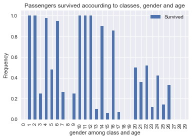

```python
pl = ASC_Passengers.Survived.mean().drop('Pclass', axis=1).plot(kind='bar',
                                                    title="Passengers survived accourding to classes, gender and age")
pl.set_xlabel('gender among class and age')
pl.set_ylabel('Frequency')
```

## 4- Are age and sex have diffrent effect on surviveing rate for various classes ?

We can see that all old agepassengers -from 65 to 80- are men and they are less likly to survive (25% for the first class) than other ages. Female passengers in most ages are more likly to survive than male passengers except children in first class the male ones are more likely to survive. We can notic that classes and gender are have strong effect on the surviving rate than age factor and it maybe for missing ages effect result accuracy.

## Conclusion

There are many limitation in this dataset. First, there are large missing in passenger records we have only 891 records from 2224 overall records. Also, these record have missing data in age and cabin failds and this affect analysis accuracy. we need more detailed information that maybe helped like adding family relations between passengers then we can measure if all family are survive or not.

## Resources:

http://matplotlib.org/examples/pie_and_polar_charts/pie_demo_features.html